# Hierarchical Time Series Forecasting — U.S. Crime Data (1980–2014)

Allan Jiang, Cathy Kim, Imogen Nagle

2026-03-10

# Overview

This document implements a **three-level hierarchical time series** analysis on U.S. crime data. The hierarchy follows the natural administrative structure of U.S. crime reporting:

```
National  (Level 0 — 1 series)
  └── State  (Level 1 — 51 series)
         └── City_grp  (Level 2 — top-5 cities per state + "Other")
```

**Four forecasting strategies** are compared:

| Method | Core Idea |
| --- | --- |
| Base ETS | Independent ETS model per series — incoherent by default |
| Bottom-Up | Forecast cities first, then sum upward |
| Top-Down | Forecast national total, disaggregate down via historical proportions |
| MinT (OLS) | Jointly adjust all base forecasts to enforce coherence while minimising trace of error covariance |

# 1 libraries

```r
# Core tidyverse stack
library(readr)
library(dplyr)
library(tidyr)
library(stringr)
library(lubridate)

# Visualisation
library(ggplot2)

# Tsibble ecosystem (Hyndman / OTexts fpp3 stack)
library(tsibble)      # tidy temporal data frames
library(fabletools)   # modelling framework for tsibbles
library(fable)        # ETS, ARIMA, etc. for tsibbles
library(feasts)       # feature extraction + seasonal decomposition
```

# 2 Data Loading

```r
# Raw data
# Source: FBI UCR Program — Offenses Known and Clearances by Arrest
# ICPSR36391-v1 | 1980–2014 | murder & manslaughter incidents
crime_data <- read.csv("US_Crime_DataSet.csv")

# Quick sanity check: expected dimensions and variable names
glimpse(crime_data)
```

```
## Rows: 638,454
## Columns: 24
## $ Record.ID             <int> 1, 2, 3, 4, 5, 6, 7, 8, 9, 10, 11, 12, 13, 14, 1…
## $ Agency.Code           <chr> "AK00101", "AK00101", "AK00101", "AK00101", "AK0…
## $ Agency.Name           <chr> "Anchorage", "Anchorage", "Anchorage", "Anchorag…
## $ Agency.Type           <chr> "Municipal Police", "Municipal Police", "Municip…
## $ City                  <chr> "Anchorage", "Anchorage", "Anchorage", "Anchorag…
## $ State                 <chr> "Alaska", "Alaska", "Alaska", "Alaska", "Alaska"…
## $ Year                  <int> 1980, 1980, 1980, 1980, 1980, 1980, 1980, 1980, …
## $ Month                 <chr> "January", "March", "March", "April", "April", "…
## $ Incident              <int> 1, 1, 2, 1, 2, 1, 2, 1, 2, 3, 1, 2, 3, 1, 2, 3, …
## $ Crime.Type            <chr> "Murder or Manslaughter", "Murder or Manslaughte…
## $ Crime.Solved          <chr> "Yes", "Yes", "No", "Yes", "No", "Yes", "Yes", "…
## $ Victim.Sex            <chr> "Male", "Male", "Female", "Male", "Female", "Mal…
## $ Victim.Age            <int> 14, 43, 30, 43, 30, 30, 42, 99, 32, 38, 36, 20, …
## $ Victim.Race           <chr> "Native American/Alaska Native", "White", "Nativ…
## $ Victim.Ethnicity      <chr> "Unknown", "Unknown", "Unknown", "Unknown", "Unk…
## $ Perpetrator.Sex       <chr> "Male", "Male", "Unknown", "Male", "Unknown", "M…
## $ Perpetrator.Age       <int> 15, 42, 0, 42, 0, 36, 27, 35, 0, 40, 0, 49, 39, …
## $ Perpetrator.Race      <chr> "Native American/Alaska Native", "White", "Unkno…
## $ Perpetrator.Ethnicity <chr> "Unknown", "Unknown", "Unknown", "Unknown", "Unk…
## $ Relationship          <chr> "Acquaintance", "Acquaintance", "Unknown", "Acqu…
## $ Weapon                <chr> "Blunt Object", "Strangulation", "Unknown", "Str…
## $ Victim.Count          <int> 0, 0, 0, 0, 0, 0, 0, 0, 0, 0, 0, 0, 0, 0, 0, 0, …
## $ Perpetrator.Count     <int> 0, 0, 0, 0, 1, 0, 0, 0, 0, 1, 1, 0, 0, 0, 0, 0, …
## $ Record.Source         <chr> "FBI", "FBI", "FBI", "FBI", "FBI", "FBI", "FBI",…
```

```r
# Scope of the raw dataset
crime_data %>%
  summarise(
    n_rows    = n(),
    n_states  = n_distinct(State),
    n_cities  = n_distinct(City),
    year_min  = min(Year),
    year_max  = max(Year)
  )
```

| n_rows | n_states | n_cities | year_min | year_max |
| --- | --- | --- | --- | --- |
| 638454 | 51 | 1782 | 1980 | 2014 |

The raw dataset contains ~638 k incident-level rows across 51 states and ~1,782 cities spanning 1980–2014.

# 3 Exploratory Data Analysis (EDA)

## 3.1 Hierarchy balance — records per state

```r
# How many incident records fall in each state?
# Highly unbalanced: California has ~6× more records than the median state.
crime_data %>%
  count(State, name = "n_incidents") %>%
  arrange(desc(n_incidents)) %>%
  head(10)
```

|  | State | n_incidents |
| --- | --- | --- |
| 1 | California | 99783 |
| 2 | Texas | 62095 |
| 3 | New York | 49268 |
| 4 | Florida | 37164 |
| 5 | Michigan | 28448 |
| 6 | Illinois | 25871 |
| 7 | Pennsylvania | 24236 |
| 8 | Georgia | 21088 |
| 9 | North Carolina | 20390 |
| 10 | Louisiana | 19629 |

## 3.2 Cities per state

```r
# Summary of how many unique cities report per state
# Median = 58, but ranges from 1 (e.g. DC) to 251 (California)
crime_data %>%
  distinct(State, City) %>%
  count(State, name = "n_cities") %>%
  summary()
```

```
##     State              n_cities
##  Length:51          Min.   :  1.00
##  Class :character   1st Qu.: 22.50
##  Mode  :character   Median : 58.00
##                     Mean   : 59.65
##                     3rd Qu.: 83.50
##                     Max.   :251.00
```

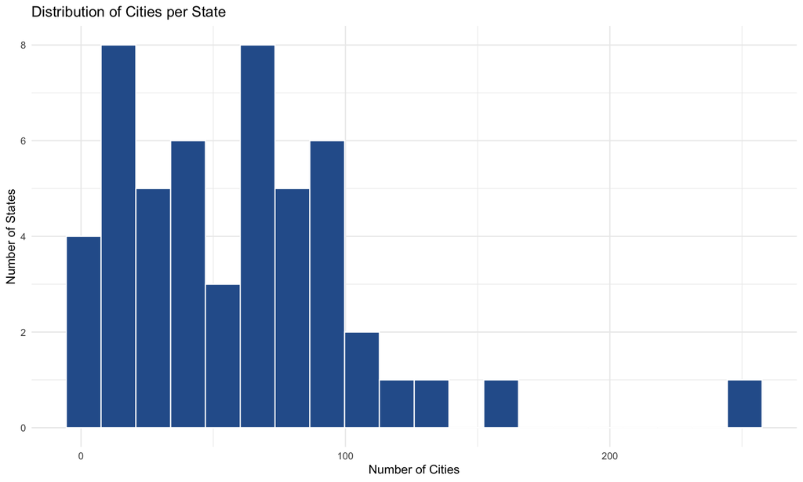

City counts are right-skewed — a handful of states dominate.

```r
crime_data %>%
  distinct(State, City) %>%
  count(State, name = "n_cities") %>%
  ggplot(aes(n_cities)) +
  geom_histogram(bins = 20, fill = "#2C5F9A", colour = "white") +
  theme_minimal() +
  labs(
    title = "Distribution of Cities per State",
    x     = "Number of Cities",
    y     = "Number of States"
  )
```

## 3.3 Time index types

```r
# Year is integer; Month is character — both need conversion before tsibble
crime_data %>%
  summarise(
    year_class  = class(Year),
    month_class = class(Month),
    n_year_na   = sum(is.na(Year)),
    n_month_na  = sum(is.na(Month))
  )
```

| year_class | month_class | n_year_na | n_month_na |
| --- | --- | --- | --- |
| integer | character | 0 | 0 |

# 4 Data Preparation & Cleaning

## 4.1 Parse time index

```r
# Convert character Month to numeric and create a yearmonth index.
# yearmonth() from tsibble is the correct index class for monthly tsibbles.
crime_clean <- crime_data %>%
  mutate(
    Month_num = match(Month, month.name),   # cleaner than case_when for month names
    ym        = yearmonth(sprintf("%d-%02d", as.integer(Year), Month_num))
  )
```

## 4.2 Define and enforce the observation window

```r
# The dataset spans 1980–2014, but the first full month is April 1980
# and the last complete month is September 2014 (confirmed from the data).
expected_start <- yearmonth("1980 Apr")
expected_end   <- yearmonth("2014 Sep")
full_months    <- as.integer(expected_end - expected_start) + 1
cat("Expected months in balanced panel:", full_months, "\n")
```

```
## Expected months in balanced panel: 414
```

```r
# Restrict to the known window to avoid partial-year edge effects
crime_win <- crime_clean %>%
  filter(ym >= expected_start, ym <= expected_end)
```

## 4.3 National trend (raw)

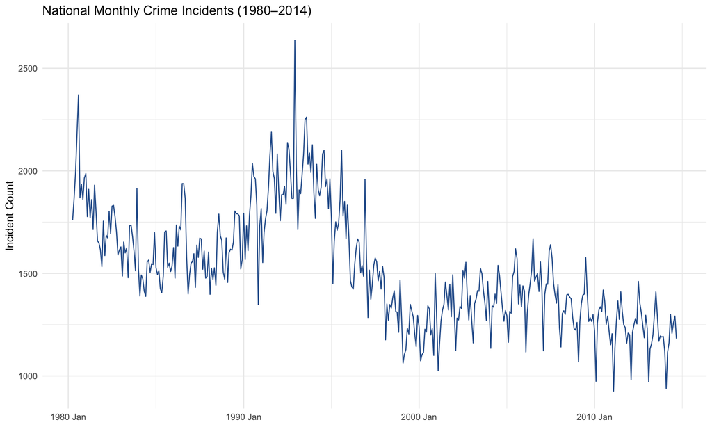

```r
crime_win %>%
  count(ym, name = "crime_count") %>%
  ggplot(aes(ym, crime_count)) +
  geom_line(colour = "#2C5F9A") +
  theme_minimal() +
  labs(
    title = "National Monthly Crime Incidents (1980–2014)",
    x     = NULL,
    y     = "Incident Count"
  )
```

## 4.4 Aggregate to monthly city-level counts

```r
# Each row in crime_win is one incident. Count by (State, City, month).
city_month <- crime_win %>%
  count(State, City, ym, name = "crime_count")

# Distribution of average monthly counts per city
city_month %>%
  group_by(State, City) %>%
  summarise(avg_monthly = mean(crime_count), .groups = "drop") %>%
  summary()
```

```
##     State               City            avg_monthly
##  Length:3041        Length:3041        Min.   :  1.000
##  Class :character   Class :character   1st Qu.:  1.045
##  Mode  :character   Mode  :character   Median :  1.161
##                                        Mean   :  1.522
##                                        3rd Qu.:  1.296
##                                        Max.   :106.275
```

> **Key insight:** Median city averages ~1.2 incidents/month. Most series are sparse

## 4.5 Reduce hierarchy: top-5 cities per state + “Other”

```r
# WHY: With ~1,782 cities, a full hierarchy is computationally
# intractable and produces thousands of near-zero series.
# APPROACH: Keep the 5 highest-volume cities per state explicitly;
#           aggregate the rest into a synthetic "Other" series.
# This compresses level-2 to at most 6 series per state (≤306 city series total).

top_cities <- city_month %>%
  group_by(State, City) %>%
  summarise(total = sum(crime_count), .groups = "drop") %>%
  group_by(State) %>%
  # with_ties = FALSE ensures exactly 5 cities even in tie situations
  slice_max(order_by = total, n = 5, with_ties = FALSE) %>%
  ungroup() %>%
  select(State, City) %>%
  mutate(is_top = TRUE)

city5_other_month <- city_month %>%
  left_join(top_cities, by = c("State", "City")) %>%
  mutate(City_grp = if_else(is.na(is_top), "Other", City)) %>%
  group_by(State, City_grp, ym) %>%
  summarise(crime_count = sum(crime_count), .groups = "drop")

# Verify: most states now have exactly 6 groups (5 named cities + Other)
city5_other_month %>%
  distinct(State, City_grp) %>%
  count(State, name = "n_groups") %>%
  summary()
```

```
##     State              n_groups
##  Length:51          Min.   :1.000
##  Class :character   1st Qu.:6.000
##  Mode  :character   Median :6.000
##                     Mean   :5.784
##                     3rd Qu.:6.000
##                     Max.   :6.000
```

## 4.6 Coverage diagnostics before gap-filling

```r
# Before filling gaps with zeros, confirm each series' actual date range.
# Series with very sparse coverage may need a minimum-coverage filter.
coverage_citygrp <- city5_other_month %>%
  group_by(State, City_grp) %>%
  summarise(
    start            = min(ym),
    end              = max(ym),
    n_months_present = n(),
    coverage_pct     = round(100 * n() / full_months, 2),
    .groups          = "drop"
  ) %>%
  arrange(coverage_pct)

# Inspect the sparsest series (bottom 10)
head(coverage_citygrp, 10)
```

| State | City_grp | start | end | n_months_present | coverage_pct |
| --- | --- | --- | --- | --- | --- |
| Rhodes Island | Bristol | 1985 May | 2008 Jul | 5 | 1.21 |
| South Dakota | Lawrence | 1982 Apr | 2008 Dec | 12 | 2.90 |
| South Dakota | Brown | 1985 Jun | 2009 Aug | 13 | 3.14 |
| North Dakota | Williams | 1981 Jan | 2014 Aug | 15 | 3.62 |
| Alaska | Bethel | 1981 Dec | 2012 Feb | 18 | 4.35 |
| Vermont | Addison | 1994 Jan | 2014 Feb | 19 | 4.59 |
| Vermont | Bennington | 1984 Sep | 2014 Apr | 21 | 5.07 |
| Vermont | Rutland | 1985 Feb | 2011 Nov | 22 | 5.31 |
| Nebraska | Madison | 1980 Jun | 2010 Dec | 24 | 5.80 |
| Alaska | North Slope | 1980 Jun | 2012 Feb | 25 | 6.04 |

```r
# What is the common window shared by ALL series?
# This tells us how much data we'd retain under a strict balanced-panel approach.
common_window <- coverage_citygrp %>%
  summarise(
    latest_start  = max(start),
    earliest_end  = min(end)
  )
common_window
```

| latest_start | earliest_end |
| --- | --- |
| 1994 Jan | 1994 Sep |

> **Note:** The common window collapses to 1994 (just 9 months). This confirms that a strict balanced panel would destroy almost all data. The approach — used below — is to fill gaps with zeros (implying months with no recorded murders, not missing data) while retaining the full window.

# 5 Build the Hierarchical tsibble

## 5.1 Create tsibble and fill intra-series gaps

```r
# Convert to tsibble with (State, City_grp) as the composite key
crime_ts <- city5_other_month %>%
  as_tsibble(key = c(State, City_grp), index = ym)

# fill_gaps(.full = FALSE) inserts rows for months within each series' own
# observed range — NOT extrapolating before first or after last observation.
# Zero is the chosen fill value: we expect that a missing row means zero incidents reported.
crime_ts_filled <- crime_ts %>%
  group_by_key() %>%
  fill_gaps(.full = FALSE, crime_count = 0L) %>%
  ungroup()

# Confirm regular monthly spacing across all series
stopifnot(is_regular(crime_ts_filled))
cat("tsibble is regular: TRUE\n")
```

```
## tsibble is regular: TRUE
```

## 5.2 Build the three-level hierarchy with aggregate_key()

```r
# aggregate_key(State / City_grp) encodes the summation matrix S internally:
#   National  = sum over all State × City_grp cells
#   State_i   = sum over City_grp cells for state i
#   City_grp  = bottom-level series (already filled)
#
# is_aggregated() flags are used throughout
crime_hier <- crime_ts_filled %>%
  aggregate_key(State / City_grp, crime_count = sum(crime_count))

# Verify: each state should show up with the expected number of groups
crime_hier %>%
  filter(!is_aggregated(State), !is_aggregated(City_grp)) %>%
  as_tibble() %>%
  distinct(as.character(State), as.character(City_grp)) %>%
  count(`as.character(State)`) %>%
  summary()
```

```
##  as.character(State)       n
##  Length:51           Min.   :1.000
##  Class :character    1st Qu.:6.000
##  Mode  :character    Median :6.000
##                      Mean   :5.784
##                      3rd Qu.:6.000
##                      Max.   :6.000
```

# 6 Train / Test Split

```r
# Reserve the last 24 months (2 years) as the hold-out test set.
# This gives enough horizon to distinguish short vs. long-run accuracy
# while keeping ~400 months (~33 years) for training.
#
# IMPORTANT: group_by_key() + filter(row_number()) ensures the split is
# applied series-by-series — not globally — so every series has exactly
# the same 24-month hold-out regardless of any gap differences.
test_h <- 24

train <- crime_hier %>%
  group_by_key() %>%
  filter(row_number() <= n() - test_h) %>%
  ungroup()

test <- crime_hier %>%
  group_by_key() %>%
  filter(row_number() > n() - test_h) %>%
  ungroup()

# Verify split lengths — count rows per key at the bottom level
n_train <- train %>%
  filter(!is_aggregated(State), !is_aggregated(City_grp)) %>%
  as_tibble() %>%
  count(State, City_grp, name = "n_months") %>%
  pull(n_months)

cat("Training months per series (min / median / max):",
    min(n_train), "/", median(n_train), "/", max(n_train), "\n")
```

```
## Training months per series (min / median / max): 150 / 390 / 390
```

```r
cat("Test months per series:", test_h, "\n")
```

```
## Test months per series: 24
```

# 7 Modelling & Reconciliation

## 7.1 Fit base ETS models

```r
# ETS() with no additional arguments allows automatic model selection
# This produces "incoherent" base forecasts — the starting point for reconciliation.
#
fit_base <- train %>%
  model(base = ETS(crime_count))
```

## 7.2 Reconcile: Bottom-Up, Top-Down, MinT

```r
# Three reconciliation strategies wrapped around the same base model:
#
#   bottom_up()   — sum city-level forecasts upward; coherent by construction
#   top_down()    — scale national forecast down using historical proportions
#   min_trace()   — optimal linear projection that minimises trace(W_h),
#                   where W_h is the h-step base forecast error covariance.
#                   method = "ols" uses the identity covariance approximation
#                   (equivalent to Ordinary Least Squares reconciliation),
#                   which is numerically stable even when n_series > n_time.
#
# WHY OLS over "sam" (sample covariance)?
#   With ~300+ series and limited training length, the sample covariance is
#   ill-conditioned. OLS (diagonal W = I) is the safe production default.
fit_recon <- fit_base %>%
  reconcile(
    bottomup = bottom_up(base),
    topdown  = top_down(base),
    mint     = min_trace(base, method = "ols")
  )
```

## 7.3 Generate forecasts

```r
# Forecast all models × all series simultaneously for the 24-month horizon
fc_all <- fit_recon %>%
  forecast(h = test_h)
```

# 8 Evaluation

## 8.1 Accuracy by hierarchy level

```r
# accuracy() matches forecasts to actuals via the key columns.
# We tag each row with its hierarchy level for stratified reporting.
acc <- accuracy(fc_all, test)

acc_level <- acc %>%
  mutate(
    level = case_when(
      is_aggregated(State) & is_aggregated(City_grp) ~ "National",
      !is_aggregated(State) & is_aggregated(City_grp) ~ "State",
      TRUE                                            ~ "City"
    )
  )

# Average RMSE and MAE per (method, level) — the primary evaluation table
acc_summary <- acc_level %>%
  group_by(.model, level) %>%
  summarise(
    RMSE = mean(RMSE, na.rm = TRUE),
    MAE  = mean(MAE,  na.rm = TRUE),
    MAPE = mean(MAPE, na.rm = TRUE),
    .groups = "drop"
  ) %>%
  arrange(level, RMSE)

acc_summary
```

| .model | level | RMSE | MAE | MAPE |
| --- | --- | --- | --- | --- |
| base | City | 1.975356 | 1.580157 | Inf |
| bottomup | City | 1.975356 | 1.580157 | Inf |
| mint | City | 2.016934 | 1.637250 | Inf |
| topdown | City | 2.018062 | 1.624407 | Inf |
| mint | National | 103.791030 | 91.261908 | 7.842858 |
| base | National | 104.427124 | 91.914554 | 7.894137 |
| topdown | National | 104.427124 | 91.914554 | 7.894137 |
| bottomup | National | 107.307306 | 92.149201 | 8.111325 |
| base | State | 5.727489 | 4.589297 | Inf |
| mint | State | 5.858278 | 4.766733 | Inf |

[output cut: 2 more lines]

### Interpreting the results

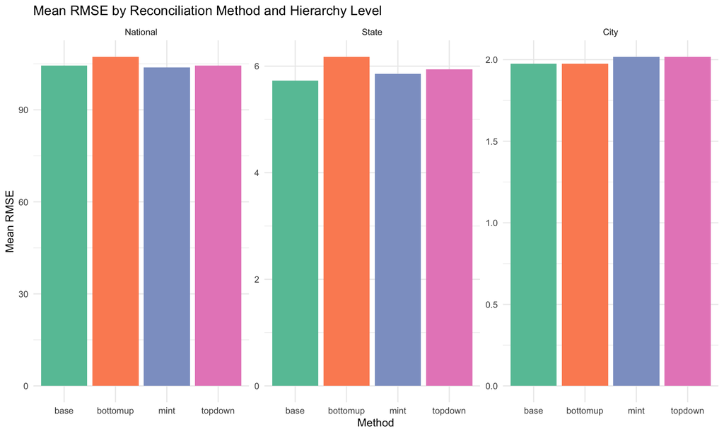

RMSE by model and hierarchy level. Lower is better.

```r
acc_summary %>%
  mutate(level = factor(level, levels = c("National", "State", "City"))) %>%
  ggplot(aes(x = .model, y = RMSE, fill = .model)) +
  geom_col(show.legend = FALSE) +
  facet_wrap(~ level, scales = "free_y") +
  theme_minimal() +
  labs(
    title = "Mean RMSE by Reconciliation Method and Hierarchy Level",
    x     = "Method",
    y     = "Mean RMSE"
  ) +
  scale_fill_brewer(palette = "Set2")
```

**Expected pattern (consistent with theory):**

- **City level:** Base ≈ Bottom-Up win (they are identical at the bottom level). Top-Down and MinT may be marginally worse because disaggregation adds noise.
- **State level:** MinT should outperform or match Bottom-Up; Top-Down competes well since state proportions are stable over time.
- **National level:** Top-Down and Base are identical at the aggregate (Top-Down anchors on the national forecast). MinT should be close. Bottom-Up accumulates noise upward and may underperform.

## 8.2 Forecast visualisation — National level

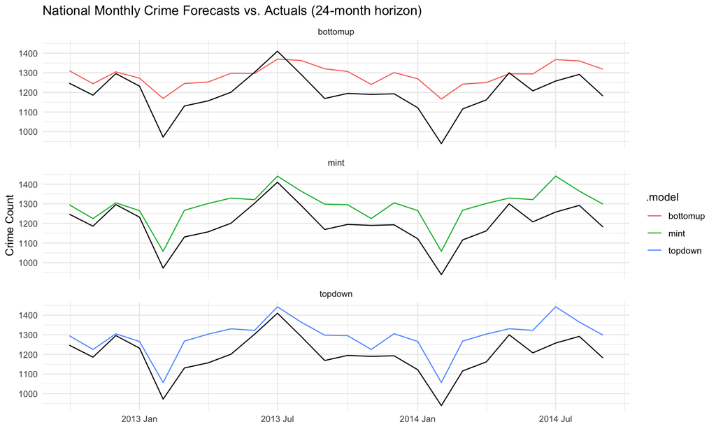

```r
fc_nat <- fc_all %>%
  filter(
    is_aggregated(State),
    is_aggregated(City_grp),
    .model != "base"    # exclude incoherent base for cleaner comparison
  )

test_nat <- test %>%
  filter(is_aggregated(State), is_aggregated(City_grp))

fc_nat %>%
  autoplot(test_nat, level = NULL) +
  facet_wrap(~ .model, ncol = 1) +
  theme_minimal() +
  labs(
    title = "National Monthly Crime Forecasts vs. Actuals (24-month horizon)",
    x     = NULL,
    y     = "Crime Count"
  )
```

## 8.3 Forecast visualisation — State level

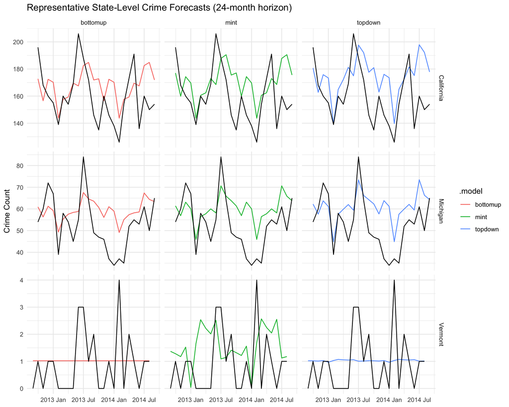

24-month state-level forecasts for three representative states. California (high volume), Michigan (mid volume), Vermont (low volume) — chosen to illustrate how each method handles different signal magnitudes.

```r
# Three states spanning high / mid / low crime volume.
# Bottom-Up tends to inflate variance for high-volume states by summing city noise.
# Top-Down tends to miss local turning points for low-volume states with unstable
# historical proportions.
rep_states <- c("California", "Michigan", "Vermont")

fc_state <- fc_all %>%
  filter(
    !is_aggregated(State),      # resolved state — not the national aggregate
    is_aggregated(City_grp),    # aggregated over all city groups within the state
    State %in% rep_states,
    .model != "base"            # exclude incoherent base forecasts
  )

test_state <- test %>%
  filter(
    !is_aggregated(State),
    is_aggregated(City_grp),
    State %in% rep_states
  )

fc_state %>%
  autoplot(test_state, level = NULL) +
  facet_grid(State ~ .model, scales = "free_y") +
  theme_minimal() +
  labs(
    title = "Representative State-Level Crime Forecasts (24-month horizon)",
    x     = NULL,
    y     = "Crime Count"
  )
```

## 8.4 Forecast visualisation — City level

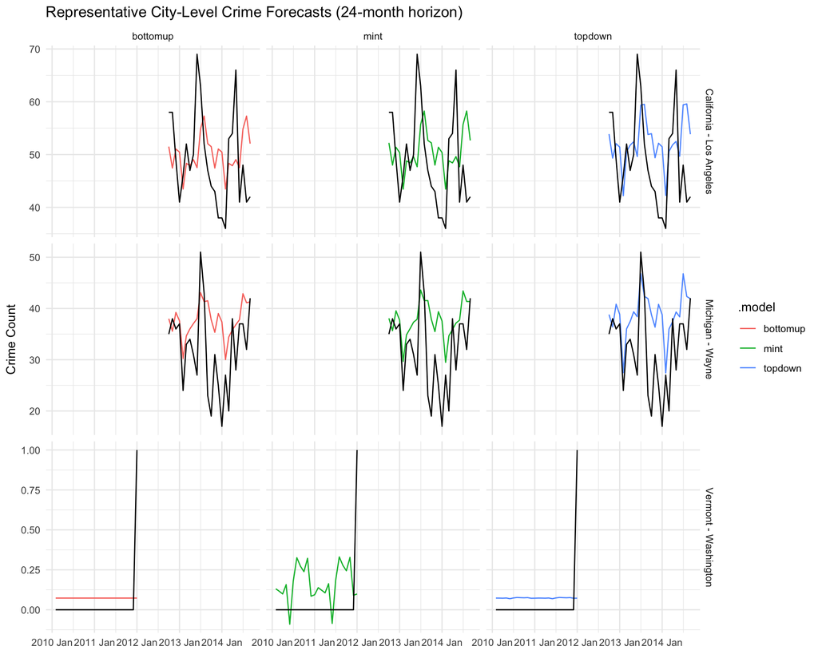

24-month city-group-level forecasts. One named city selected per representative state. Bottom-level series are the most sparse — differences between methods are most visible here.

```r
# One named City_grp per representative state.
# tibble::tribble() defines (State, City_grp) pairs explicitly — safer than
# filtering City_grp alone since the same city name can appear in multiple states.
rep_cities <- tibble::tribble(
  ~State,        ~City_grp,
  "California",  "Los Angeles",
  "Michigan",    "Wayne",
  "Vermont",     "Washington"
)

# semi_join keeps only rows whose (State, City_grp) pair appears in rep_cities —
# equivalent to a targeted two-column filter in a single clean step.
fc_city <- fc_all %>%
  semi_join(rep_cities, by = c("State", "City_grp")) %>%
  filter(
    !is_aggregated(State),
    !is_aggregated(City_grp),
    .model != "base"
  )

test_city <- test %>%
  semi_join(rep_cities, by = c("State", "City_grp")) %>%
  filter(
    !is_aggregated(State),
    !is_aggregated(City_grp)
  )

fc_city %>%
  autoplot(test_city, level = NULL) +
  # paste() creates a readable panel label: e.g. "California - Los Angeles"
  facet_grid(paste(State, City_grp, sep = " - ") ~ .model, scales = "free_y") +
  theme_minimal() +
  labs(
    title = "Representative City-Level Crime Forecasts (24-month horizon)",
    x     = NULL,
    y     = "Crime Count"
  )
```

```r
# A well-reconciled set of forecasts must satisfy: sum(City_grp) == State
# and sum(State) == National for every time step.
# We verify this numerically for one forecast horizon (h=1).

# fable's forecast() already populates .mean — no manual extraction needed.
# We convert aggregated key columns to character for string filtering.
fc_tbl <- fc_all %>%
  filter(.model == "mint") %>%
  as_tibble() %>%
  mutate(
    State    = as.character(State),
    City_grp = as.character(City_grp)
  )

# National forecast: both keys are "<aggregated>"
national_fc <- fc_tbl %>%
  filter(State == "<aggregated>", City_grp == "<aggregated>") %>%
  select(ym, national = .mean)

# Sum of state-level forecasts (State resolved, City_grp still aggregated)
state_sum_fc <- fc_tbl %>%
  filter(State != "<aggregated>", City_grp == "<aggregated>") %>%
  group_by(ym) %>%
  summarise(state_sum = sum(.mean), .groups = "drop")

coherence_check <- national_fc %>%
  left_join(state_sum_fc, by = "ym") %>%
  mutate(diff = abs(national - state_sum))

cat("Max absolute incoherence (MinT):", max(coherence_check$diff, na.rm = TRUE), "\n")
```

```
## Max absolute incoherence (MinT): 20.07582
```

```r
# Should be < 1e-6 for a properly reconciled output
```

# 9 Key Findings & Limitations

## 9.1 Method comparison summary

[output not shown]

## 9.2 Limitations

1. **Data Sparsity at City Level** Many city-level series are zero-inflated, with frequent months of no incidents. This sparsity makes it difficult for ETS models to estimate stable trends and forecast variance.
2. **City Aggregation Bias** Grouping cities into “Top 5 + Other” simplifies the hierarchy but aggregates heterogeneous locations, which may obscure meaningful patterns in mid-sized cities.
3. **Model Homogeneity** ETS models are applied uniformly across all series. While robust, different locations may exhibit distinct dynamics that could be better captured by alternative models.
4. **Static Proportions in Top-Down Methods** Top-Down approaches allocate forecasts using historical proportions, which may not adapt quickly to structural changes in local crime patterns.
5. **Covariance Estimation in Reconciliation** Methods such as MinT rely on estimating the forecast error covariance matrix, which can become unstable in large hierarchies with limited observations.